# Chapter 2

# Data analysis exercise

## Data description

Data aims to model the relationship between learning approaches and students achievements in an introductory statistics course in Finland. There are total of 7 variables which explain the students achievements (points). Variables are “gender”, “Age”, “Attitude”,“Deep”,“Stra” and “Surf”.

### Data dimensions

Data has 166 observations (students) and 7 variables. Hence, data is a table with 166 rows and 7 columns.

> Variables:
- Age; Age (in years) derived from the date of birth
- Attitude; Global attitude toward statistics
- Points; Exam points
- gender; Gender: M (Male), F (Female)
- Deep; Deep approach ~d_sm+d_ri+d_ue where, d_sm = Seeking Meaning d_ri = Relating Ideas d_ue = Use of Evidence
- Surf; Surface approach ~su_lp+su_um+su_sb where, su_lp = Lack of Purpose su_um = Unrelated Memorising su_sb = Syllabus-boundness
- Stra; Strategic approach ~st_os+st_tm where, st_os = Organized Studying st_tm = Time Management

### Variable statistics

```r
url = "http://s3.amazonaws.com/assets.datacamp.com/production/course_2218/datasets/learning2014.txt"
data_stud <- read.delim(url, sep=",")
summary(data_stud)
```

```
##  gender       age           attitude          deep            stra
##  F:110   Min.   :17.00   Min.   :1.400   Min.   :1.583   Min.   :1.250
##  M: 56   1st Qu.:21.00   1st Qu.:2.600   1st Qu.:3.333   1st Qu.:2.625
##          Median :22.00   Median :3.200   Median :3.667   Median :3.188
##          Mean   :25.51   Mean   :3.143   Mean   :3.680   Mean   :3.121
##          3rd Qu.:27.00   3rd Qu.:3.700   3rd Qu.:4.083   3rd Qu.:3.625
##          Max.   :55.00   Max.   :5.000   Max.   :4.917   Max.   :5.000
##       surf           points
##  Min.   :1.583   Min.   : 7.00
##  1st Qu.:2.417   1st Qu.:19.00
##  Median :2.833   Median :23.00
##  Mean   :2.787   Mean   :22.72
##  3rd Qu.:3.167   3rd Qu.:27.75
##  Max.   :4.333   Max.   :33.00
```

## Data Visualization

### Plots

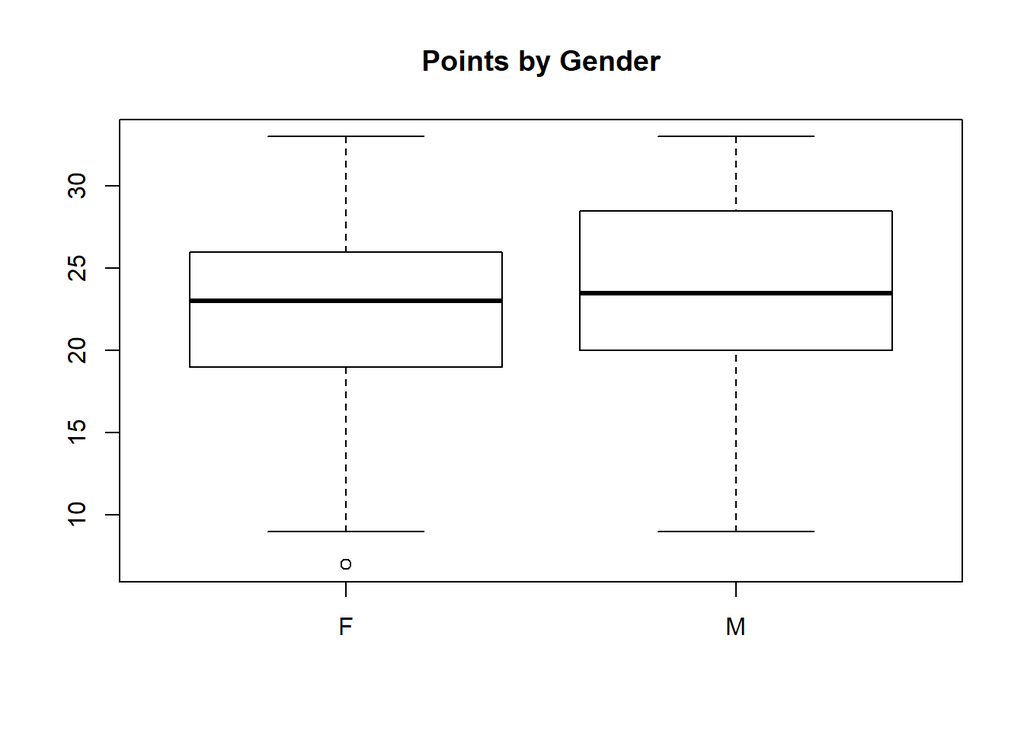

```r
url = "http://s3.amazonaws.com/assets.datacamp.com/production/course_2218/datasets/learning2014.txt"
data_stud <- read.delim(url, sep=",")
boxplot(split(data_stud$points,data_stud$gender),main='Points by Gender')
```

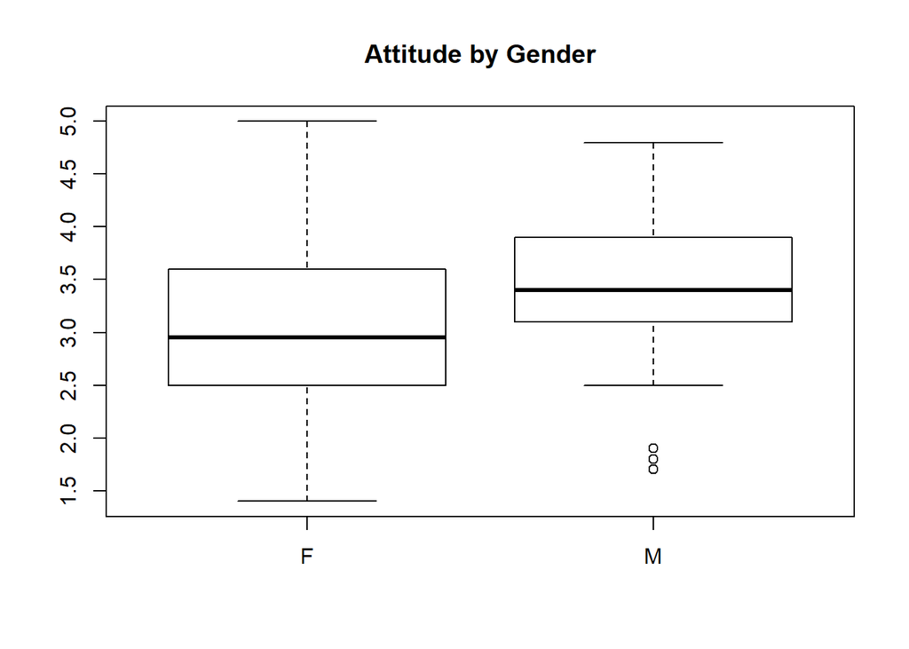

```r
boxplot(split(data_stud$attitude,data_stud$gender),main='Attitude by Gender')
```

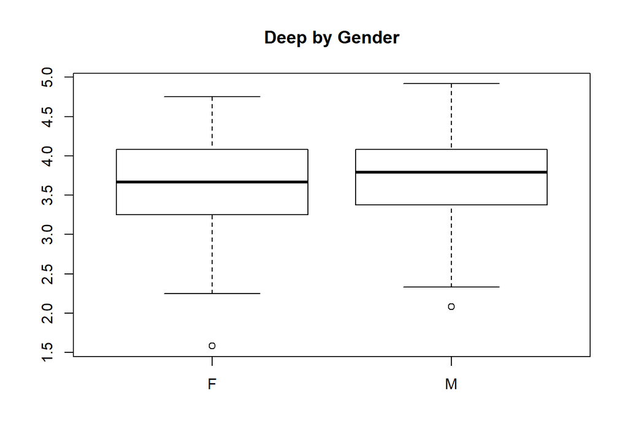

```r
boxplot(split(data_stud$deep,data_stud$gender),main='Deep by Gender')
```

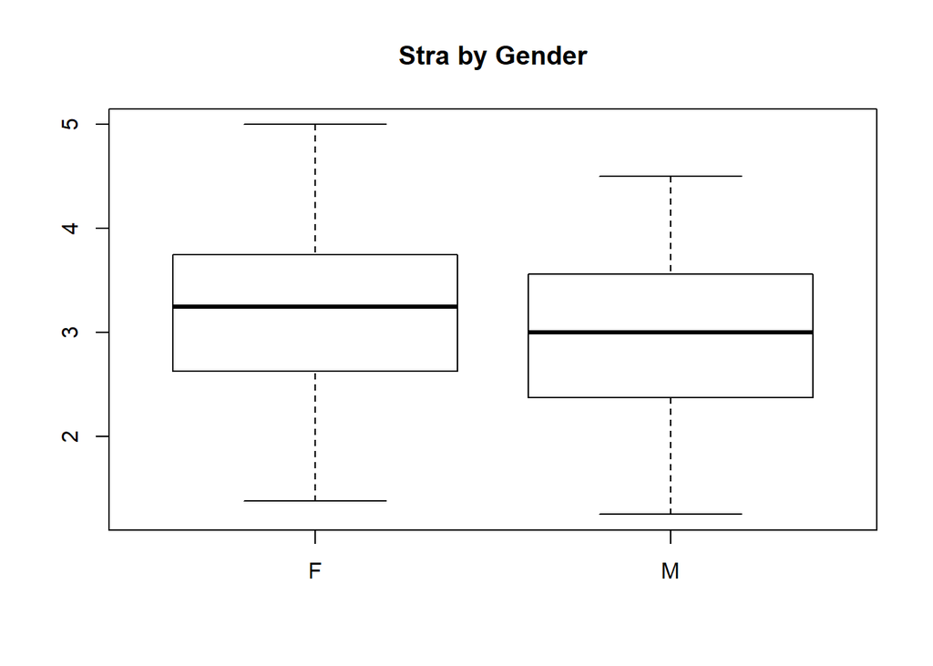

```r
boxplot(split(data_stud$stra,data_stud$gender),main='Stra by Gender')
```

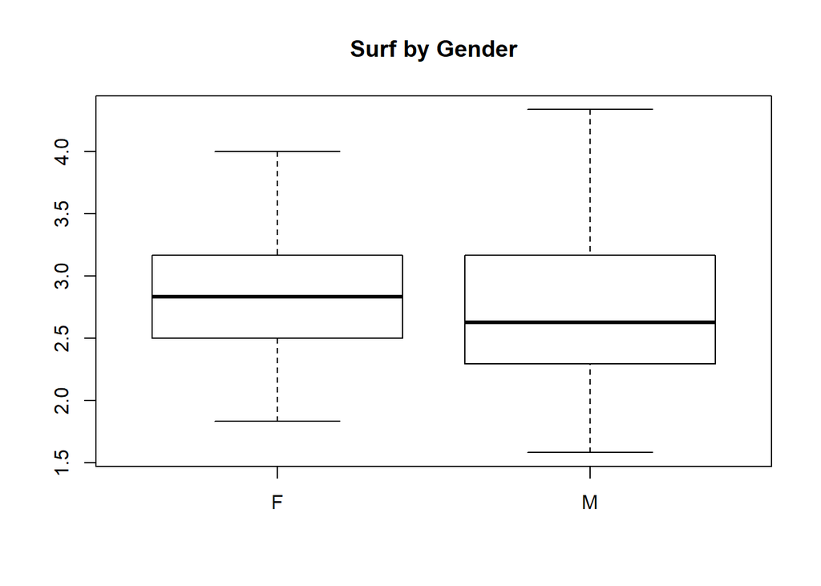

```r
boxplot(split(data_stud$surf,data_stud$gender),main='Surf by Gender')
```

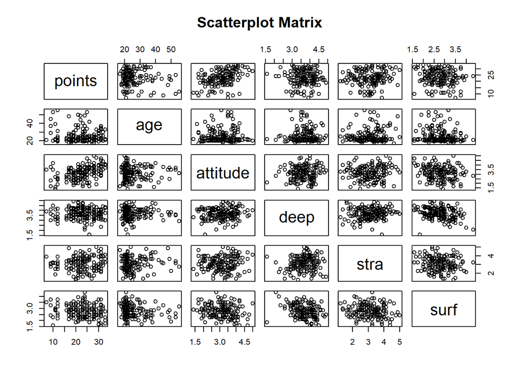

```r
pairs(~points+age+attitude+deep+stra+surf,data=data_stud,
   main="Scatterplot Matrix")
```

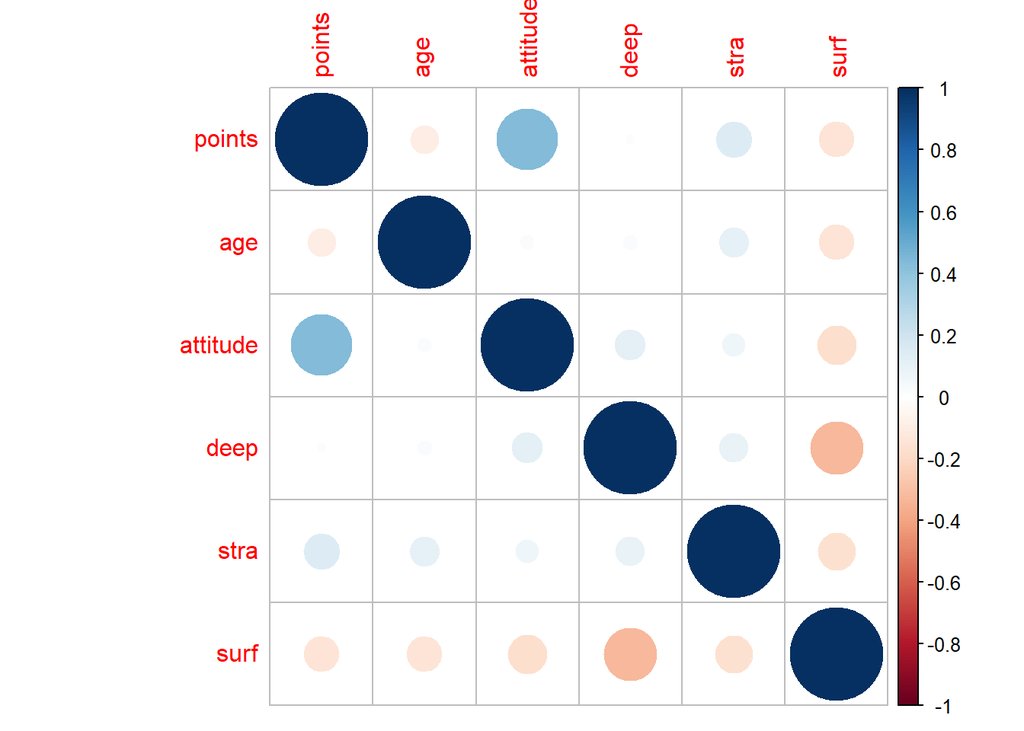

```r
library(corrplot)
data_stud$gender <- factor(data_stud$gender)
num_data <- data_stud[,c("points","age","attitude","deep","stra","surf")]
res <- cor(num_data)
corrplot(as.matrix(res), method="circle")
```

## Comments on data

### Gender

There seems to be slight variation in points between the genders:

```r
url = "http://s3.amazonaws.com/assets.datacamp.com/production/course_2218/datasets/learning2014.txt"
data_stud <- read.delim(url, sep=",")
tapply(data_stud$points, data_stud$gender, mean)
```

```
##        F        M
## 22.32727 23.48214
```

Difference in mean points is (23.48214-22.32727) = 1.16

**Conclusion:** males tend to get slightly higher points than women.

Interesting feature between genders is that especially in attitude-variable (which describes general attitude towards statistics) is higher in males than females. Females on the other hand, are higher at stra (strategic approach: organizing studies and time management). Females might find lack of purpose in statistic related studies and studying it might include unrealted memorising because of it (Surf).

### Age

When looking at age-variable, one should note that there is extremely high number of occurences 20-30-years category: it might give us bad image from how age truly affects the total points of student.

Correlation between points and age:

```r
url = "http://s3.amazonaws.com/assets.datacamp.com/production/course_2218/datasets/learning2014.txt"
data_stud <- read.delim(url, sep=",")
with(data_stud, cor(age, points))
```

```
## [1] -0.09319032
```

Correlation is negative.

**Conclusion:** older the student is - lower the points are. Although, correlation is not particularly strong.

### Attitude, Stra, Deep and Surf

Correlations between students attitude and study habits, and exam points.

```r
url = "http://s3.amazonaws.com/assets.datacamp.com/production/course_2218/datasets/learning2014.txt"
data_stud <- read.delim(url, sep=",")
with(data_stud, cor(attitude, points))
```

```
## [1] 0.4365245
```

```r
with(data_stud, cor(stra, points))
```

```
## [1] 0.1461225
```

```r
with(data_stud, cor(deep, points))
```

```
## [1] -0.01014849
```

```r
with(data_stud, cor(surf, points))
```

```
## [1] -0.1443564
```

The best variable which indicates students points is, by far, **attitude**. Correlation is 0.44.

Stra and Surf are give second best interpretiations: Students with strategic approach tend to get better points, on the other hand Surf decreases students points (Lack of Purpose, Unrelated Memorising, Syllabus-boundness).

## Correlations between the descriptive variables

Strategic approach (Stra) correlates positively between all the variables, except Surf.

# Fitting regression model

## Model parameters

I chose three explanatory variables which are:

- Attitude
- Stra
- Age

```r
url = "http://s3.amazonaws.com/assets.datacamp.com/production/course_2218/datasets/learning2014.txt"
l_model <- lm(points ~ attitude + stra + age, data=data_stud)
summary(l_model)
```

```
##
## Call:
## lm(formula = points ~ attitude + stra + age, data = data_stud)
##
## Residuals:
##      Min       1Q   Median       3Q      Max
## -18.1149  -3.2003   0.3303   3.4129  10.7599
##
## Coefficients:
##             Estimate Std. Error t value Pr(>|t|)
## (Intercept) 10.89543    2.64834   4.114 6.17e-05 ***
## attitude     3.48077    0.56220   6.191 4.72e-09 ***
## stra         1.00371    0.53434   1.878   0.0621 .
## age         -0.08822    0.05302  -1.664   0.0981 .
## ---
## Signif. codes:  0 '***' 0.001 '**' 0.01 '*' 0.05 '.' 0.1 ' ' 1
##
## Residual standard error: 5.26 on 162 degrees of freedom
## Multiple R-squared:  0.2182, Adjusted R-squared:  0.2037
## F-statistic: 15.07 on 3 and 162 DF,  p-value: 1.07e-08
```

### What it does?

Multiple linear regression explains the relationship between descriptive variables (attitude, stra, age) and response variables (points). Model fits linear (linear line, bluntly) equation to observed data.

### Results

Although, some of the explanatory variables show statistical significance in linear model, the R-squared value of the whole model stays rather low: 0.20.

Model: Points_est = 10.89543 + (3.48077*attitude) + (1.00371*stra) - (0.08822*age)

### Re-model, without age

```r
url = "http://s3.amazonaws.com/assets.datacamp.com/production/course_2218/datasets/learning2014.txt"
l_model <- lm(points ~ attitude + stra, data=data_stud)
summary(l_model)
```

```
##
## Call:
## lm(formula = points ~ attitude + stra, data = data_stud)
##
## Residuals:
##      Min       1Q   Median       3Q      Max
## -17.6436  -3.3113   0.5575   3.7928  10.9295
##
## Coefficients:
##             Estimate Std. Error t value Pr(>|t|)
## (Intercept)   8.9729     2.3959   3.745  0.00025 ***
## attitude      3.4658     0.5652   6.132 6.31e-09 ***
## stra          0.9137     0.5345   1.709  0.08927 .
## ---
## Signif. codes:  0 '***' 0.001 '**' 0.01 '*' 0.05 '.' 0.1 ' ' 1
##
## Residual standard error: 5.289 on 163 degrees of freedom
## Multiple R-squared:  0.2048, Adjusted R-squared:  0.1951
## F-statistic: 20.99 on 2 and 163 DF,  p-value: 7.734e-09
```

### Results without age

Model got worse without age-variable. R-squared in new model 0.19. Conclusion: continue with attitude, stra and age.

## Diagnostic plots

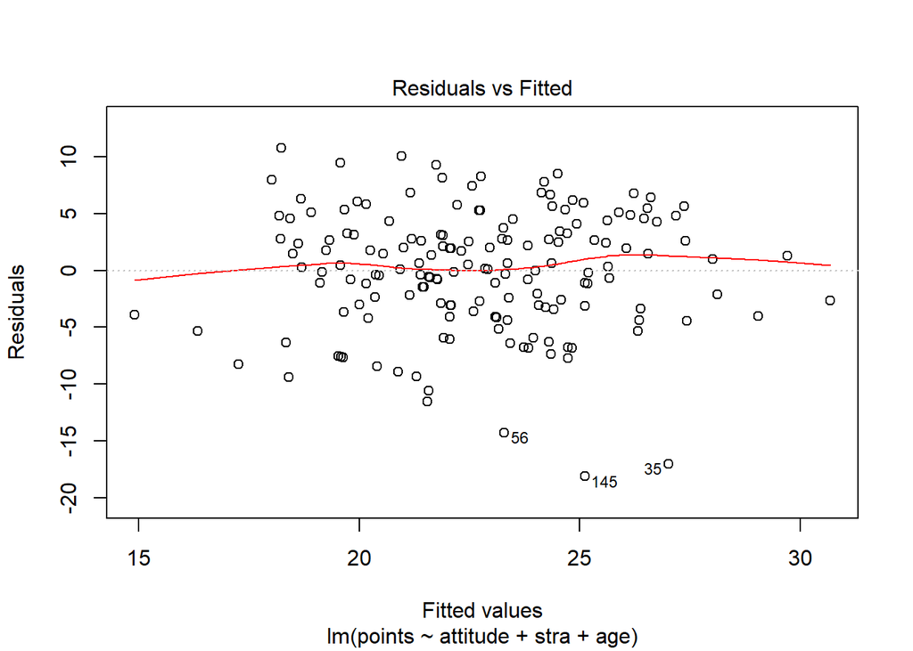

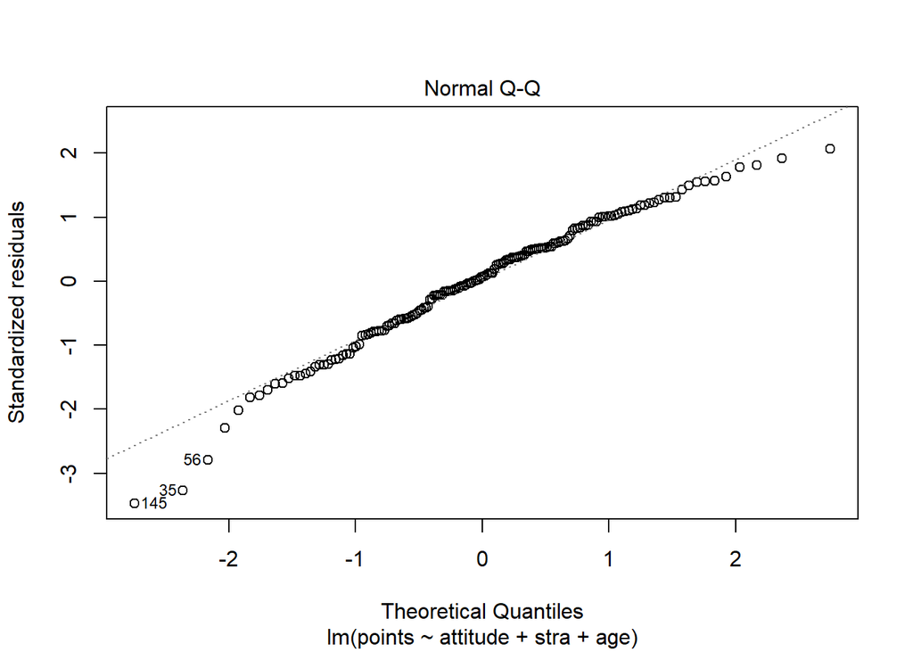

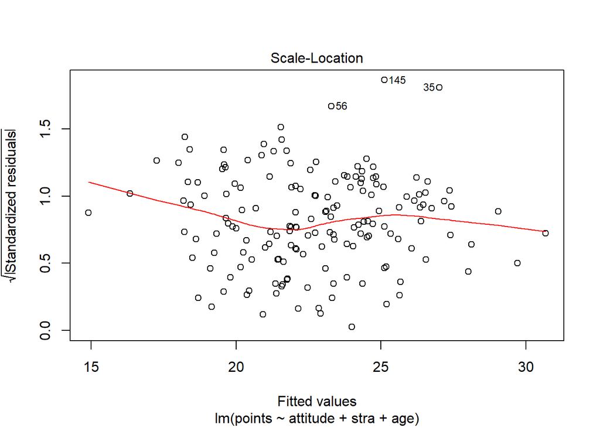

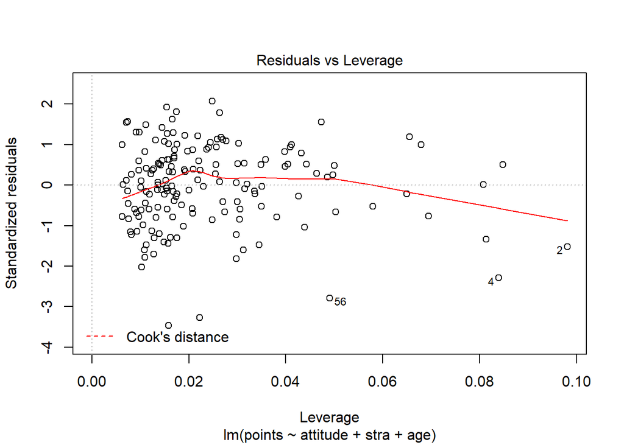

```r
url = "http://s3.amazonaws.com/assets.datacamp.com/production/course_2218/datasets/learning2014.txt"
l_model <- lm(points ~ attitude + stra + age, data=data_stud)
plot(l_model)
```

## Diagnostics interpretation

**Aim** of the diagnostics plots is to explain how well our multilinear model is actually fitting the data.

### Residuals vs Fitted

Scatterplot represents the correlation between model residuals and predicted values. If residuals are small, the model predicts well. On the other hand, if the scatterplot seems sparse, it indicates that model is not giving good predictions. Remember, out model R^2 was only 0.2.

### QQ-plot

Normal Q-Q-plot is a normal probability plot: if errors in model follow normal distribution, line is straight. In our case, there seems to be slight divergence from normal distribution in both ends. Extremely low and high points are harder to predict with the model.

### Residuals vs Leverage

Last plot describes the influence of observations in the model. We can interpret from the plot that obs. 56, 4 and 2 have the most influence to our model. We could go back to the original data and check is there something wrong with it, or make conclusion why these particular students have such a different point - attitude - stra - and age combinations. They are not clearly following the trend.